# ROC Curve

ChatGPT 4o

2025-01-21

## 1 起源

ROC曲线（Receiver Operating Characteristic Curve，受试者工作特征曲线）最早出现在20世纪40年代，用于雷达信号检测，以评估检测器的识别性能。随着统计学的发展，ROC曲线逐渐被引入到生物医学领域，成为评估二分类模型性能的重要工具。如今，ROC曲线已广泛用于医学诊断、机器学习、信号检测等领域，帮助研究人员评估模型的分类性能和区分能力。

## 2 原理

ROC曲线通过绘制灵敏度（Sensitivity）与1-特异性（1-Specificity）的关系，来评价二分类模型的性能。

- **混淆矩阵**：二分类模型的评估通常使用混淆矩阵，定义如下：

  |  | 预测为正 (Positive) | 预测为负 (Negative) |
  | --- | --- | --- |
  | 实际为正 (Positive) | 真正例 (TP) | 假负例 (FN) |
  | 实际为负 (Negative) | 假正例 (FP) | 真负例 (TN) |

  在混淆矩阵中：
  - **TP（True Positive）**：正确预测为正的样本数量。
  - **TN（True Negative）**：正确预测为负的样本数量。
  - **FP（False Positive）**：错误预测为正的样本数量。
  - **FN（False Negative）**：错误预测为负的样本数量。
- **灵敏度（Sensitivity）**：又称为真正率，表示模型正确预测正例的比例。
  $$\text{Sensitivity} = \frac{TP}{TP + FN}$$
  其中，$TP$为真正例数，$FN$为假负例数。
- **特异性（Specificity）**：表示模型正确预测负例的比例。
  $$\text{Specificity} = \frac{TN}{TN + FP}$$
  其中，$TN$为真负例数，$FP$为假正例数。
- **1-特异性（1-Specificity）**：表示模型错误预测负例的比例，即假阳性率。

ROC曲线的横轴是1-特异性，纵轴是灵敏度。通过改变决策阈值，得到一系列的（1-特异性，灵敏度）点并绘制曲线。曲线下的面积（AUC，Area Under the Curve）用于量化模型的性能。AUC值越大，表示模型的区分能力越强。

- **AUC**：AUC的取值范围是0到1。AUC值越接近1，表示模型的预测效果越好；AUC值为0.5时，表示模型的预测效果等同于随机猜测。

## 3 适用范围

ROC曲线适用于以下情况：

- **二分类问题**：ROC曲线专门用于评估二分类模型的性能，如是否患病、是否合格等。
- **评估模型性能**：适合在模型性能不平衡时进行比较，如对正负样本不均衡的数据进行评估。
- **多模型比较**：可以通过比较多个模型的ROC曲线和AUC值来选择最优模型。

## 4 应用情境

ROC曲线在多个领域中有广泛的应用，例如：

- **医学诊断**：用于评估不同诊断测试的灵敏度和特异性，帮助选择最佳的诊断工具。
- **机器学习**：在机器学习模型中，尤其是二分类模型，ROC曲线用于评估模型的分类性能。
- **金融风控**：在信用评分和欺诈检测中，ROC曲线用于评估模型对欺诈行为的识别能力。
- **信号检测**：在信号检测理论中，ROC曲线用于评估检测器对目标信号的识别效果。

## 5 优缺点

### 优点

- **全面评估模型性能**：ROC曲线可以直观地显示模型在不同阈值下的分类性能，适合评估模型的整体表现。
- **适用于不平衡数据**：与准确率相比，ROC曲线对类别不平衡的数据更为敏感，因为它关注的是灵敏度和特异性。
- **可比较多个模型**：通过比较不同模型的ROC曲线和AUC值，可以直观地选择性能更优的模型。

### 缺点

- **只能用于二分类问题**：ROC曲线主要用于二分类问题，对于多分类问题需要进行转化。
- **不适用于高度不平衡数据的极端情况**：在高度不平衡的数据中，ROC曲线可能高估模型的性能。
- **依赖于阈值选择**：ROC曲线的形状和AUC值依赖于模型的阈值选择，可能需要对阈值进行细致调整。

## 6 在R中的实现及结果解释

在R中，可以使用`pROC`包来绘制ROC曲线并计算AUC。以下是一个实现ROC曲线的示例：

```r
# 加载必要的包
library(pROC)
```

```r
library(ggplot2)

# 示例数据：生成假设的预测概率和真实标签
set.seed(123)
data <- data.frame(
  true_labels = sample(c(0, 1), 100, replace = TRUE),
  predicted_probs = runif(100)
)

# 计算ROC曲线
roc_result <- roc(data$true_labels, data$predicted_probs)
summary(roc_result)
```

```
##                    Length Class  Mode
## percent              1    -none- logical
## sensitivities      101    -none- numeric
## specificities      101    -none- numeric
## thresholds         101    -none- numeric
## direction            1    -none- character
## cases               43    -none- numeric
## controls            57    -none- numeric
## fun.sesp             1    -none- function
## auc                  1    auc    numeric
## call                 3    -none- call
## original.predictor 100    -none- numeric
## original.response  100    -none- numeric
## predictor          100    -none- numeric
## response           100    -none- numeric
## levels               2    -none- character
```

```r
str(roc_result)
```

[output not shown]

```r
# 输出AUC值
auc_value <- auc(roc_result)
print(paste("AUC:", auc_value))
```

```
## [1] "AUC: 0.561811505507956"
```

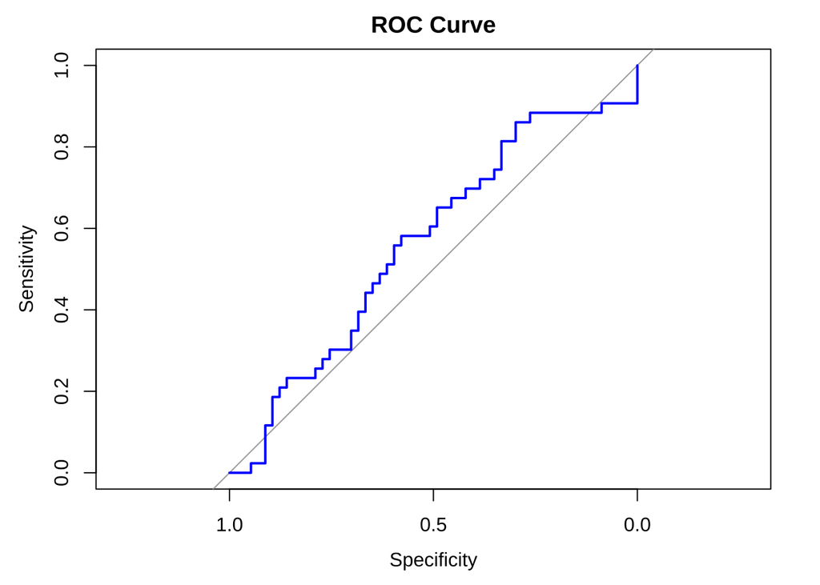

```r
# 绘制ROC曲线
plot(roc_result, main = "ROC Curve", col = "blue")
```

### 结果解释

- **AUC值**：通过`auc(roc_result)`可以得到模型的AUC值，用于量化模型的性能。AUC值越接近1，表示模型区分正负样本的能力越强。
- **ROC曲线**：通过`plot(roc_result)`绘制ROC曲线，曲线的形状表示模型在不同阈值下的性能。曲线越靠近左上角，说明模型的分类性能越好。

### 结果的可视化

ROC曲线用于可视化二分类模型的性能，可以直观地显示模型在不同阈值下的灵敏度和特异性。

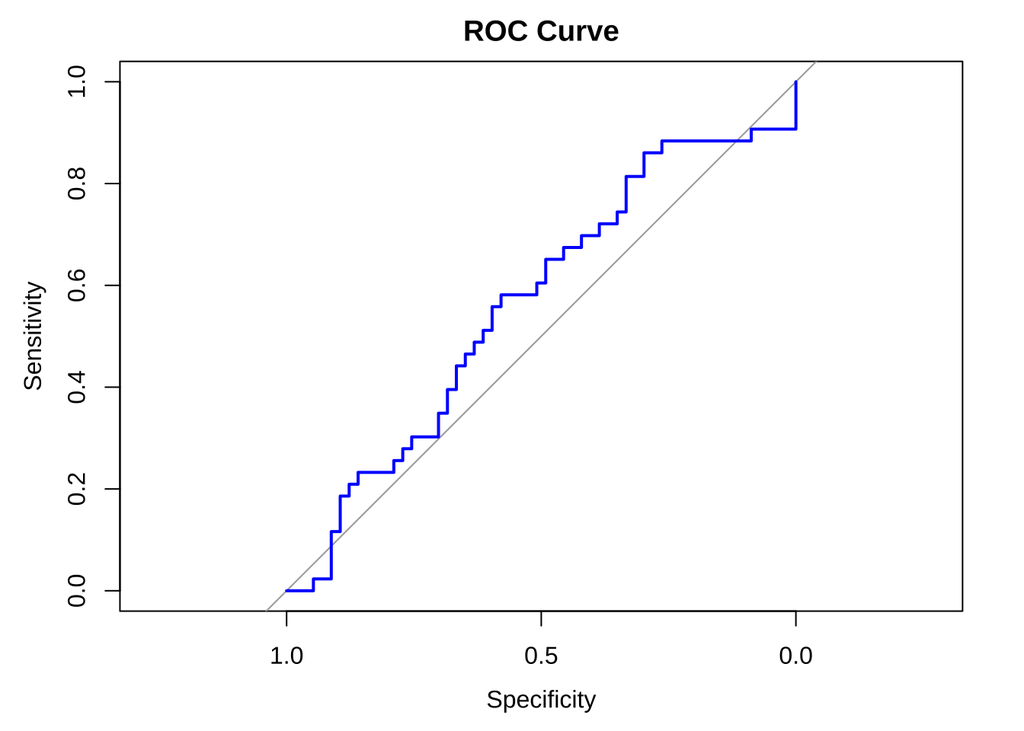

```r
# 绘制ROC曲线
plot(roc_result, main = "ROC Curve", col = "blue")
```

## 7 小结

- ROC曲线是一种用于评估二分类模型性能的工具，通过绘制灵敏度与1-特异性的关系来评估模型的区分能力。
- 适用于评估二分类模型的整体表现，尤其是在类别不平衡的数据中。
- 具有全面评估模型性能、适用于不平衡数据和可比较多个模型的优点，但只能用于二分类问题，并且在高度不平衡的数据中可能会高估模型性能。
- 可以通过R中的`pROC`包实现ROC曲线的绘制，并结合AUC值量化模型的性能。
- ROC曲线在医学诊断、机器学习、金融风控等领域有着广泛的应用，是评估分类模型性能的重要工具。